# PRODUCTO ACADEMICO FINAL - Introducción a los Modelos Estadísticos

Autores: Jimm Campos Bravo, Nicolas Augusto Marin Lora, Alex Lenin Zapana Apaza, Pamela Verenice Jimenez Soncco, y Carmen Rosa Pata Cardenas

2025-01-20

# 1.1. Explicación de la Problematica

Las enfermedades cardiovasculares (ECV) representan una de las principales causas de morbilidad y mortalidad a nivel mundial. Factores como el estilo de vida, el nivel socioeconómico y la educación tienen una influencia significativa en la incidencia de estas enfermedades. Sin embargo, muchas organizaciones de salud y políticas públicas carecen de información detallada y estructurada que les permita identificar patrones clave y tomar decisiones basadas en datos para prevenir y mitigar el impacto de las ECV en la población.

El presente análisis busca abordar la problemática de cómo los factores socioeconómicos y de estilo de vida afectan la prevalencia de enfermedades cardiovasculares en una población ficticia representativa. Específicamente, se examinan variables como:

El nivel educativo y su posible relación con la prevención de enfermedades. La zona de residencia (urbana o rural) y su influencia en el acceso a servicios de salud. El hábito de fumar como un factor de riesgo determinante. Los ingresos mensuales, que pueden impactar el acceso a una alimentación saludable y a la atención médica adecuada. Objetivo del Análisis El propósito es identificar patrones y correlaciones entre estas variables para responder preguntas clave como:

- ¿Existe una relación significativa entre el nivel educativo y la presencia de enfermedades cardiovasculares?
- ¿Las personas con ingresos más bajos tienen una mayor prevalencia de enfermedades cardiovasculares?
- ¿El hábito de fumar está más presente en ciertos grupos demográficos o socioeconómicos?

```r
# Cargar librerías necesarias
library(tibble)
library(dplyr)
install.packages("writexl")
library(writexl)
```

```r
# Definir el número de filas
num_rows <- 100
```

```r
# Listas de valores posibles
set.seed(123)  # Fijar semilla para reproducibilidad
genero_options <- c("Hombre", "Mujer")
nivel_educativo_options <- c("Primaria", "Secundaria", "Universitario", "Posgrado")
estado_civil_options <- c("Soltero", "Casado", "Viudo")
zona_residencia_options <- c("Urbana", "Rural")
fuma_options <- c("Sí", "No")
enfermedades_options <- c("Sí", "No")
```

```r
# Generar el dataset
dataset <- tibble(
  ID = 1:num_rows,
  Edad = sample(18:65, num_rows, replace = TRUE),
  Género = sample(genero_options, num_rows, replace = TRUE),
  Nivel_Educativo = sample(nivel_educativo_options, num_rows, replace = TRUE),
  Ingreso_Mensual = sample(seq(800, 6000, by = 50), num_rows, replace = TRUE),
  Estado_Civil = sample(estado_civil_options, num_rows, replace = TRUE),
  Zona_Residencia = sample(zona_residencia_options, num_rows, replace = TRUE),
  Horas_Estudio_Semana = sample(0:40, num_rows, replace = TRUE),
  Fuma = sample(fuma_options, num_rows, replace = TRUE),
  Enfermedades_Cardiovasculares = sample(enfermedades_options, num_rows, replace = TRUE)
)
```

```r
# Mostrar una vista previa del dataset
head(dataset)
```

```
## # A tibble: 6 × 10
##      ID  Edad Género Nivel_Educativo Ingreso_Mensual Estado_Civil
##   <int> <int> <chr>  <chr>                     <dbl> <chr>
## 1     1    48 Hombre Universitario              4050 Casado
## 2     2    32 Mujer  Primaria                    950 Casado
## 3     3    31 Hombre Secundaria                 4450 Soltero
## 4     4    20 Mujer  Secundaria                 5600 Casado
## 5     5    59 Mujer  Primaria                   1000 Soltero
## 6     6    60 Mujer  Posgrado                   2000 Casado
## # ℹ 4 more variables: Zona_Residencia <chr>, Horas_Estudio_Semana <int>,
## #   Fuma <chr>, Enfermedades_Cardiovasculares <chr>
```

```r
# Guardar el dataset en un archivo Excel
write_xlsx(dataset, "dataset_factores_socioeconomicos.xlsx")
```

# 1.2 Explicación del Dataset

# 1.3 Planteamiento de Hipótesis

Basándonos en las variables del dataset, se plantean las siguientes hipótesis para su análisis:

Hipótesis 1: Los hábitos de fumar incrementan el riesgo de enfermedades cardiovasculares. Hipótesis nula (H₀): No existe una relación significativa entre el hábito de fumar y la presencia de enfermedades cardiovasculares. Hipótesis alternativa (H₁): Las personas que fuman tienen una mayor probabilidad de padecer enfermedades cardiovasculares en comparación con las que no fuman.

Hipótesis 2: Las personas con menor nivel educativo tienen un mayor riesgo de padecer enfermedades cardiovasculares. Hipótesis nula (H₀): No hay relación entre el nivel educativo y la presencia de enfermedades cardiovasculares. Hipótesis alternativa (H₁): Un nivel educativo más bajo está asociado con una mayor prevalencia de enfermedades cardiovasculares.

Hipótesis 3: Existen diferencias en los ingresos mensuales según el nivel educativo alcanzado. Hipótesis nula (H₀): El nivel educativo no influye en los ingresos mensuales de la población estudiada. Hipótesis alternativa (H₁): Las personas con niveles educativos más altos tienden a tener ingresos mensuales mayores.

# 1.4. Análisis exploratorio o descriptivo de los datos (tablas de frecuencia, tablas de contingencia, gráficos en plot o ggplot, tablas de correlaciones)

```r
# Carga y exploraciónb de los datos

set.seed(123)

dataset <- data.frame(
  ID = 1:100,
  Edad = sample(18:65, 100, replace = TRUE),
  Género = sample(c("Hombre", "Mujer"), 100, replace = TRUE),
  Nivel_Educativo = sample(c("Primaria", "Secundaria", "Universitario", "Posgrado"), 100, replace = TRUE),
  Ingreso_Mensual = sample(800:6000, 100, replace = TRUE),
  Estado_Civil = sample(c("Soltero", "Casado", "Viudo"), 100, replace = TRUE),
  Zona_Residencia = sample(c("Urbana", "Rural"), 100, replace = TRUE),
  Horas_Estudio_Semana = sample(0:40, 100, replace = TRUE),
  Fuma = sample(c("Sí", "No"), 100, replace = TRUE),
  Enfermedades_Cardiovasculares = sample(c("Sí", "No"), 100, replace = TRUE)
)
```

```r
# Mostrar las primeras filas de la data
head(dataset)
```

```
##   ID Edad Género Nivel_Educativo Ingreso_Mensual Estado_Civil Zona_Residencia
## 1  1   48 Hombre   Universitario            3425      Soltero           Rural
## 2  2   32  Mujer        Primaria            3177      Soltero           Rural
## 3  3   31 Hombre      Secundaria            5012        Viudo           Rural
## 4  4   20  Mujer      Secundaria            5543      Soltero           Rural
## 5  5   59  Mujer        Primaria            1878       Casado          Urbana
## 6  6   60  Mujer        Posgrado            2040       Casado           Rural
##   Horas_Estudio_Semana Fuma Enfermedades_Cardiovasculares
## 1                   37   No                            Sí
## 2                    9   No                            No
## 3                   37   Sí                            No
## 4                   40   Sí                            Sí
## 5                    7   No                            No
## 6                    0   No                            Sí
```

```r
library(ggplot2)
library(dplyr)
install.packages("corrplot")
library(corrplot)
library(knitr)
```

```r
# Tablas de frecuencia

# Frecuencia de Género
tabla_genero <- table(dataset$Género)
kable(tabla_genero)
```

| Var1 | Freq |
| --- | --- |
| Hombre | 43 |
| Mujer | 57 |

```r
# Frecuencia de Nivel Educativo
tabla_educacion <- table(dataset$Nivel_Educativo)
kable(tabla_educacion)
```

| Var1 | Freq |
| --- | --- |
| Posgrado | 18 |
| Primaria | 38 |
| Secundaria | 26 |
| Universitario | 18 |

```r
# Frecuencia de Enfermedades Cardiovasculares
tabla_enfermedades <- table(dataset$Enfermedades_Cardiovasculares)
kable(tabla_enfermedades)
```

| Var1 | Freq |
| --- | --- |
| No | 50 |
| Sí | 50 |

```r
# Tabla de contingencia

# Relación entre Género y Enfermedades Cardiovasculares
tabla_contingencia_genero <- table(dataset$Género, dataset$Enfermedades_Cardiovasculares)
kable(tabla_contingencia_genero)
```

|  | No | Sí |
| --- | --- | --- |
| Hombre | 18 | 25 |
| Mujer | 32 | 25 |

```r
# Relación entre Fumar y Enfermedades Cardiovasculares
tabla_contingencia_fuma <- table(dataset$Fuma, dataset$Enfermedades_Cardiovasculares)
kable(tabla_contingencia_fuma)
```

|  | No | Sí |
| --- | --- | --- |
| No | 28 | 24 |
| Sí | 22 | 26 |

```r
# Relación entre Nivel Educativo y Enfermedades Cardiovasculares
tabla_contingencia_educacion <- table(dataset$Nivel_Educativo, dataset$Enfermedades_Cardiovasculares)
kable(tabla_contingencia_educacion)
```

|  | No | Sí |
| --- | --- | --- |
| Posgrado | 11 | 7 |
| Primaria | 21 | 17 |
| Secundaria | 12 | 14 |
| Universitario | 6 | 12 |

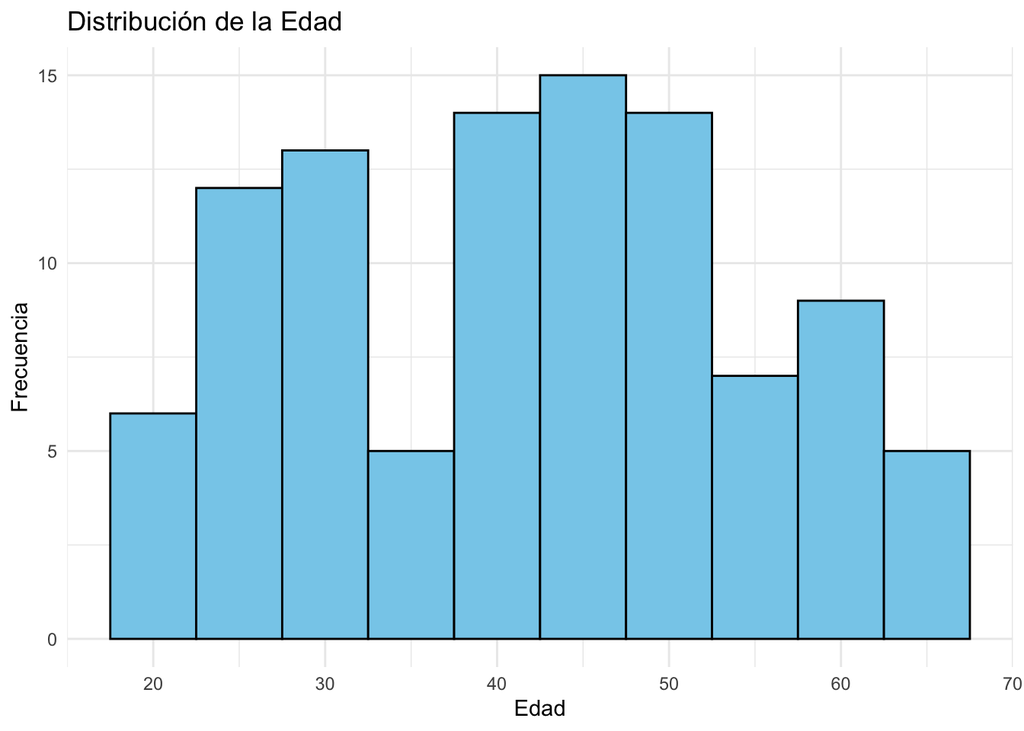

```r
# Graficos exploratorios

# Histograma de edades
ggplot(dataset, aes(x = Edad)) +
  geom_histogram(binwidth = 5, fill = "skyblue", color = "black") +
  labs(title = "Distribución de la Edad", x = "Edad", y = "Frecuencia") +
  theme_minimal()
```

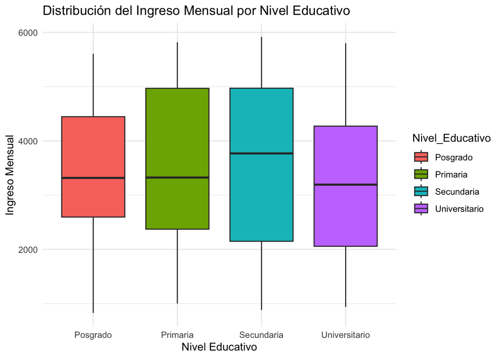

```r
# Boxplot del Ingreso Mensual por Nivel Educativo
ggplot(dataset, aes(x = Nivel_Educativo, y = Ingreso_Mensual, fill = Nivel_Educativo)) +
  geom_boxplot() +
  labs(title = "Distribución del Ingreso Mensual por Nivel Educativo", x = "Nivel Educativo", y = "Ingreso Mensual") +
  theme_minimal()
```

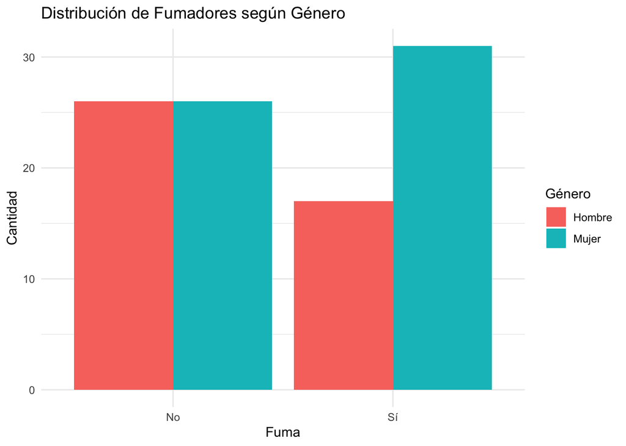

```r
# Comparación de hábito de fumar por género
ggplot(dataset, aes(x = Fuma, fill = Género)) +
  geom_bar(position = "dodge") +
  labs(title = "Distribución de Fumadores según Género", x = "Fuma", y = "Cantidad") +
  theme_minimal()
```

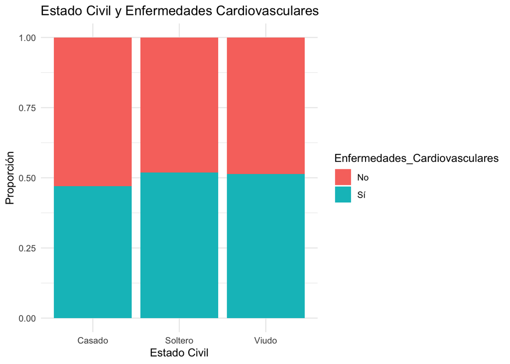

```r
# Gráfico de barras del estado civil
ggplot(dataset, aes(x = Estado_Civil, fill = Enfermedades_Cardiovasculares)) +
  geom_bar(position = "fill") +
  labs(title = "Estado Civil y Enfermedades Cardiovasculares", x = "Estado Civil", y = "Proporción") +
  theme_minimal()
```

```r
# Matriz de correlaciones

# Selección de variables numéricas para análisis de correlación
dataset_numerico <- dataset %>%
  select(Edad, Ingreso_Mensual, Horas_Estudio_Semana)
```

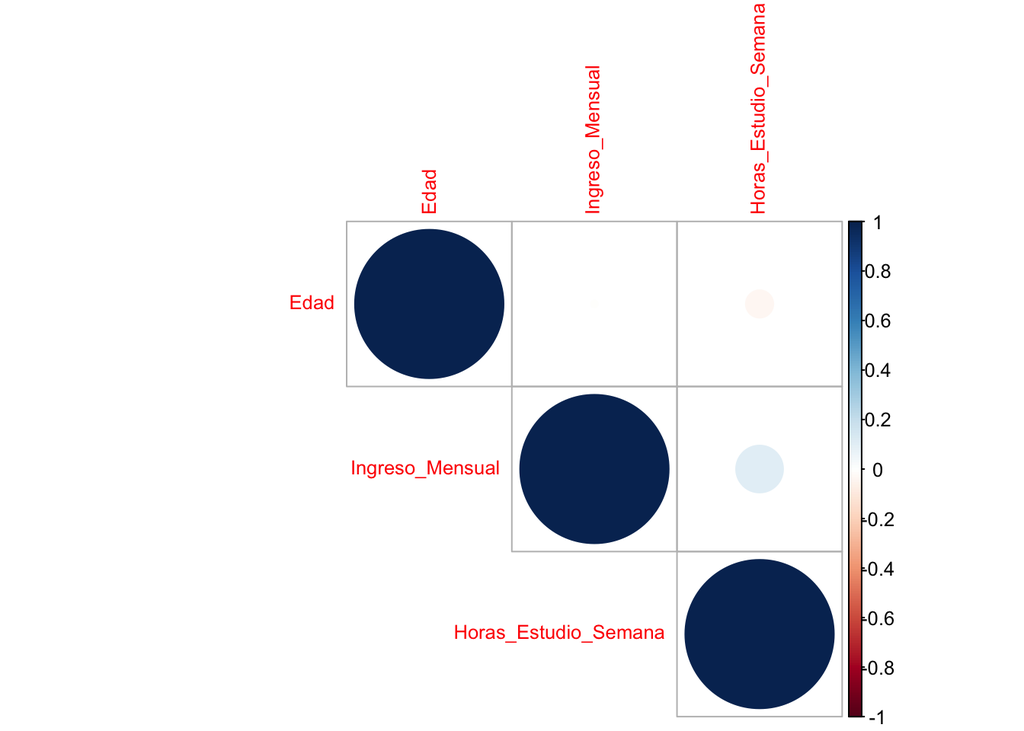

```r
# Cálculo de la matriz de correlación
matriz_correlacion <- cor(dataset_numerico)

# Visualización de la matriz de correlación
corrplot(matriz_correlacion, method = "circle", type = "upper", tl.cex = 0.8)
```